# PA 9.2

Our dataset consists of clinical data from patients who entered the hospital complaining of chest pain (“angina”) during exercise. The information collected includes:

- `age` : Age of the patient
- `sex` : Sex of the patient
- `cp` : Chest Pain type
  - Value 0: asymptomatic
  - Value 1: typical angina
  - Value 2: atypical angina
  - Value 3: non-anginal pain
- `trtbps` : resting blood pressure (in mm Hg)
- `chol` : cholesterol in mg/dl fetched via BMI sensor
- `restecg` : resting electrocardiographic results
  - Value 0: normal
  - Value 1: having ST-T wave abnormality (T wave inversions and/or ST elevation or depression of > 0.05 mV)
  - Value 2: showing probable or definite left ventricular hypertrophy by Estes’ criteria
- `thalach` : maximum heart rate achieved during exercise
- `output` : the doctor’s diagnosis of whether the patient is at risk for a heart attack
  - 0 = not at risk of heart attack
  - 1 = at risk of heart attack

```python
## library imports here
import pandas as pd
import numpy as np
import matplotlib.pyplot as plt
import seaborn as sns
from sklearn.pipeline import Pipeline
from sklearn.neighbors import KNeighborsClassifier
from sklearn.tree import DecisionTreeClassifier
from sklearn.linear_model import LogisticRegression
from sklearn.discriminant_analysis import LinearDiscriminantAnalysis
from sklearn.preprocessing import *
from sklearn.model_selection import *
from sklearn.metrics import *
from sklearn.compose import *
from sklearn.tree import *
from sklearn.svm import *
import sklearn.discriminant_analysis
```

```python
ha = pd.read_csv("https://www.dropbox.com/s/aohbr6yb9ifmc8w/heart_attack.csv?dl=1")
ha.head()
```

|  | age | sex | cp | trtbps | chol | restecg | thalach | output |
| --- | --- | --- | --- | --- | --- | --- | --- | --- |
| 0 | 63 | 1 | 3 | 145 | 233 | 0 | 150 | 1 |
| 1 | 37 | 1 | 2 | 130 | 250 | 1 | 187 | 1 |
| 2 | 56 | 1 | 1 | 120 | 236 | 1 | 178 | 1 |
| 3 | 57 | 0 | 0 | 120 | 354 | 1 | 163 | 1 |
| 4 | 57 | 1 | 0 | 140 | 192 | 1 | 148 | 1 |

## Q1: Natural Multiclass Models

Fit a multiclass KNN, Decision Tree, and LDA for the heart disease data; this time predicting the type of chest pain (categories 0 - 3) that a patient experiences. For the decision tree, plot the fitted tree, and interpret the first couple splits.

```python
X = ha[["age","chol","trtbps"]]
y = ha["cp"]

cv = 5
X_train,X_test,y_train,y_test = train_test_split(X,y,test_size=0.3,random_state=321)
```

```python
ct_knn = ColumnTransformer([
    ("standardize", StandardScaler(), make_column_selector(dtype_include=np.number))
])

pipeline_knn = Pipeline([
    ("ct", ct_knn),
    ("knn", KNeighborsClassifier())
])

paramGrid = {"knn__n_neighbors": range(1,11)}
search = GridSearchCV(pipeline_knn, paramGrid,cv=cv,scoring="accuracy")
```

```python
KNN_fit = search.fit(X_train, y_train)
pd.DataFrame(search.cv_results_).sort_values("rank_test_score")[["param_knn__n_neighbors","mean_test_score","rank_test_score"]]
```

|  | param_knn__n_neighbors | mean_test_score | rank_test_score |
| --- | --- | --- | --- |
| 6 | 7 | 0.486910 | 1 |
| 8 | 9 | 0.465857 | 2 |
| 9 | 10 | 0.455466 | 3 |
| 1 | 2 | 0.449933 | 4 |
| 7 | 8 | 0.444939 | 5 |
| 5 | 6 | 0.434683 | 6 |
| 4 | 5 | 0.429420 | 7 |
| 3 | 4 | 0.429285 | 8 |
| 2 | 3 | 0.413360 | 9 |
| 0 | 1 | 0.356140 | 10 |

```python
testPredictions_knn = KNN_fit.predict(X_test)

cm = confusion_matrix(y_test, testPredictions_knn)

accuracyKNN = accuracy_score(y_test, testPredictions_knn)
recallKNN = recall_score(y_test, testPredictions_knn, average='weighted')
precisionKNN = precision_score(y_test, testPredictions_knn, average='weighted')
f1KNN = f1_score(y_test, testPredictions_knn, average='weighted')

print("KNN")
print(f"Accuracy: {accuracyKNN:.2f}")
print(f"Recall: {recallKNN:.2f}")
print(f"Precision: {precisionKNN:.2f}")
print(f"F1 Score: {f1KNN:.2f}")
```

```
KNN
Accuracy: 0.33
Recall: 0.33
Precision: 0.28
F1 Score: 0.29
```

```python
testPredictionProbs = KNN_fit.predict_proba(X_test)
rocKNN = roc_auc_score(y_test, testPredictionProbs, multi_class='ovr', average='weighted')
print(f"The optimal KNN model produces a ROC_AUC score of {rocKNN:.4f}")
```

```
The optimal KNN model produces a ROC_AUC score of 0.4556
```

```python
# DT Model
ct_dt = ColumnTransformer([
    ("standardize", StandardScaler(), make_column_selector(dtype_include=np.number))
])

pipeline_dt = Pipeline([
    ("ct", ct_dt),
    ("model", DecisionTreeClassifier(max_depth=2))
])


dt_Model = pipeline_dt.fit(X_train, y_train)
```

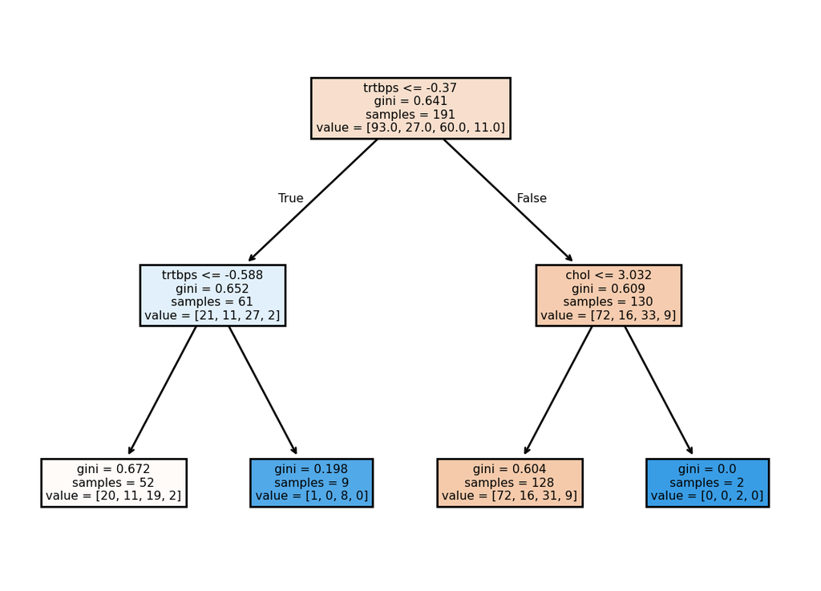

```python
plot_tree(dt_Model.named_steps["model"], feature_names=["trtbps", "chol", "age"], filled=True)
plt.figure(figsize=(10,10))
plt.show()
```

```python
testPredictions_dt = dt_Model.predict(X_test)

cm = confusion_matrix(y_test, testPredictions_dt)

accuracyDT = accuracy_score(y_test, testPredictions_dt)
recallDT = recall_score(y_test, testPredictions_dt, average='weighted')
precisionDT = precision_score(y_test, testPredictions_dt, average='weighted')
f1DT = f1_score(y_test, testPredictions_dt, average='weighted')

print("DT")
print(f"Accuracy: {accuracyDT:.2f}")
print(f"Recall: {recallDT:.2f}")
print(f"Precision: {precisionDT:.2f}")
print(f"F1 Score: {f1DT:.2f}")
```

```
DT
Accuracy: 0.40
Recall: 0.40
Precision: 0.25
F1 Score: 0.28
```

```python
testPredictionProbs = dt_Model.predict_proba(X_test)
rocDT = roc_auc_score(y_test, testPredictionProbs, multi_class='ovr', average='weighted')
print(f"The optimal KNN model produces a ROC_AUC score of {rocDT:.4f}")
```

```
The optimal KNN model produces a ROC_AUC score of 0.5830
```

```python
#LDA Model
ct_lda = ColumnTransformer([
    ("standardize", StandardScaler(), make_column_selector(dtype_include=np.number))
])

pipeline_lda = Pipeline([
    ("ct", ct_dt),
    ('lda', sklearn.discriminant_analysis.LinearDiscriminantAnalysis())
])


lda_Model = pipeline_lda.fit(X_train, y_train)
```

```python
testPredictions_lda = lda_Model.predict(X_test)

cm = confusion_matrix(y_test, testPredictions_lda)

accuracyLDA = accuracy_score(y_test, testPredictions_lda)
recallLDA = recall_score(y_test, testPredictions_lda, average='weighted')
precisionLDA = precision_score(y_test, testPredictions_lda, average='weighted')
f1LDA = f1_score(y_test, testPredictions_lda, average='weighted')

print("LDA")
print(f"Accuracy: {accuracyLDA:.2f}")
print(f"Recall: {recallLDA:.2f}")
print(f"Precision: {precisionLDA:.2f}")
print(f"F1 Score: {f1LDA:.2f}")
```

```
LDA
Accuracy: 0.41
Recall: 0.41
Precision: 0.26
F1 Score: 0.31
```

```python
testPredictionProbs = lda_Model.predict_proba(X_test)
rocLDA = roc_auc_score(y_test, testPredictionProbs, multi_class='ovr', average='weighted')
print(f"The optimal KNN model produces a ROC_AUC score of {rocLDA:.4f}")
```

```
The optimal KNN model produces a ROC_AUC score of 0.5206
```

## Q2: OvR

Create a new column in the `ha` dataset called `cp_is_3`, which is equal to `1` if the `cp` variable is equal to `3` and `0` otherwise.

Then, fit a Logistic Regression to predict this new target, and report the **F1 Score**.

Repeat for the other three `cp` categories. Which category was the OvR approach best at distinguishing?

```python
ha["cp_is_3"] = np.where(ha["cp"] == 3, 1, 0)
ha["cp_is_2"] = np.where(ha["cp"] == 2, 1, 0)
ha["cp_is_1"] = np.where(ha["cp"] == 1, 1, 0)
ha["cpPis_0"] = np.where(ha["cp"] == 0, 1, 0)

y3 = ha["cp_is_3"]
y2 = ha["cp_is_2"]
y1 = ha["cp_is_1"]
y0 = ha["cpPis_0"]

X_train,X_test,y_train,y_test = train_test_split(X,y2,test_size=0.3,random_state=321)
```

```python
# Logistic
ct_log = ColumnTransformer([
    ("standardize", StandardScaler(), make_column_selector(dtype_include=np.number))
])



pipeline_log = Pipeline([
  ("logistic_regression", LogisticRegression())]
)

log_Model = pipeline_log.fit(X_train, y_train)
```

```python
testPredictions_log = log_Model.predict(X_test)

cm = confusion_matrix(y_test, testPredictions_lda)

f1LOG = f1_score(y_test, testPredictions_log, average='weighted')

print("Logistic 1")
print(f"F1 Score: {f1LOG:.2f}")
```

```
Logistic 1
F1 Score: 0.63
```

```python
def run_ovr(y):
    X_train, X_test, y_train, y_test = train_test_split(X, y, test_size=0.3, random_state=321)


    ct = ColumnTransformer([
        ("standardize", StandardScaler(), make_column_selector(dtype_include="number"))
    ])

    pipeline_log = Pipeline([
        ("logistic_regression", LogisticRegression())
    ])

    log_Model = pipeline_log.fit(X_train, y_train)

    testPredictions_log = log_Model.predict(X_test)

    f1 = np.round(f1_score(y_test, testPredictions_log, average='weighted'),4)

    return f1
```

```python
print(f"Y2 {run_ovr(y2)}")
print(f"Y3 {run_ovr(y3)}")
print(f"y1 {run_ovr(y1)}")
print(f"y0 {run_ovr(y0)}")
```

```
Y2 0.6347
Y3 0.8386
y1 0.701
y0 0.4856
```

CP 3 had the higest F1 score of 0.8386 meaning it does the best job at balancing both precision and recall and is best at distinguishing.

## Q3: OvO

Reduce your dataset to only the `0` and `1` types of chest pain.

Then, fit a Logistic Regression to predict between the two groups, and report the **ROC-AUC**.

Repeat comparing category `0` to `2` and `3`. Which pair was the OvO approach best at distinguishing?

```python
y1 = ha[ha["cp"].isin([0,1])]["cp"].replace({0:0, 1:1})
y2 = ha[ha["cp"].isin([0,2])]["cp"].replace({0:0, 2:1})
y3 = ha[ha["cp"].isin([0,3])]["cp"].replace({0:0, 3:1})
```

```python
def run_ovo(y):

    X_sub = X.loc[y.index]

    X_train, X_test, y_train, y_test = train_test_split(
        X_sub, y, test_size=0.3, random_state=321
    )

    ct = ColumnTransformer([
        ("standardize", StandardScaler(), make_column_selector(dtype_include="number"))
    ])

    pipeline_log = Pipeline([
        ("preprocess", ct),
        ("logistic_regression", LogisticRegression(max_iter=1000))
    ])

    model = pipeline_log.fit(X_train, y_train)
    y_prob = model.predict_proba(X_test)[:, 1]

    auc = np.round(roc_auc_score(y_test, y_prob),4)
    return auc
```

```python
print("0 vs 1:", run_ovo(y1))
print("0 vs 2:", run_ovo(y2))
print("0 vs 3:", run_ovo(y3))
```

```
0 vs 1: 0.7081
0 vs 2: 0.5
0 vs 3: 0.7778
```

0 vs 3 had the highest AUC at 0.7778 meaning it was the best pair at distinguishing